# Exploring the Bechdel Test and its Significance

Amanbeer Khanduja

2021-12-06

# Introduction

This project deals with the inherent discrimination and gender bias in the movie industry, focusing here on Hollywood movies released between 1990 to 2013. We’re going to study this using what is known as the Bechdel Test. There are caveats to using the Bechdel test - it is by no means perfect or all-inclusive, but it is one of the few tests that has a lot of data available to analyse, and is basic enough that it isn’t too narrow a metric either.

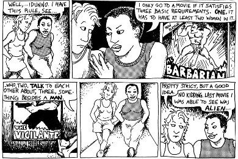

> “If a movie can satisfy three criteria — there are at least two named women in the picture, they have a conversation with each other at some point, and that conversation isn’t about a male character — then it passes “The Rule”, whereby female characters are allocated a bare minimum of depth."

I’m interested in this topic because firstly, I am fond of movies, and have often done the Bechdel analysis on movies myself before. This is by no means something that people have just come around to doing, after all the test is 25 years old at this point, but I think exploring this in R would be very interesting. Secondly, a test such as this one is highly subjective beyond a PASS or FAIL rating, which also stood out to me as an interesting thing to consider when I was looking for datasets.

# Data

I picked up this dataset from the FiveThirtyEight article titled [‘The Dollar-And-Cents Case Against Hollywood’s Exclusion of Women’](https://fivethirtyeight.com/features/the-dollar-and-cents-case-against-hollywoods-exclusion-of-women/).

Since this dataset is composed based on user submission, some inherent user bias is expected. People inclined to watch movies that are more realistic when it comes to depicting women, even in a metric as basic as this, would like to add those movies to the website’s dataset, pushing their score upward. Thus, the 3% difference is attributed towards bias.

For the questions that I have in mind, I will be utilizing all the variables from the dataset.

```r
str(rawData)
```

```
## tibble [1,794 x 15] (S3: tbl_df/tbl/data.frame)
##  $ year          : int [1:1794] 2013 2012 2013 2013 2013 2013 2013 2013 2013 2013 ...
##  $ imdb          : chr [1:1794] "tt1711425" "tt1343727" "tt2024544" "tt1272878" ...
##  $ title         : chr [1:1794] "21 &amp; Over" "Dredd 3D" "12 Years a Slave" "2 Guns" ...
##  $ test          : chr [1:1794] "notalk" "ok-disagree" "notalk-disagree" "notalk" ...
##  $ clean_test    : chr [1:1794] "notalk" "ok" "notalk" "notalk" ...
##  $ binary        : chr [1:1794] "FAIL" "PASS" "FAIL" "FAIL" ...
##  $ budget        : int [1:1794] 13000000 45000000 20000000 61000000 40000000 225000000 92000000 12000000 13000000 130000000 ...
##  $ domgross      : int [1:1794] 25682380 13414714 53107035 75612460 95020213 38362475 67349198 15323921 18007317 60522097 ...
##  $ intgross      : num [1:1794] 4.22e+07 4.09e+07 1.59e+08 1.32e+08 9.50e+07 ...
##  $ code          : chr [1:1794] "2013FAIL" "2012PASS" "2013FAIL" "2013FAIL" ...
##  $ budget_2013.  : int [1:1794] 13000000 45658735 20000000 61000000 40000000 225000000 92000000 12000000 13000000 130000000 ...
##  $ domgross_2013.: int [1:1794] 25682380 13611086 53107035 75612460 95020213 38362475 67349198 15323921 18007317 60522097 ...
##  $ intgross_2013.: num [1:1794] 4.22e+07 4.15e+07 1.59e+08 1.32e+08 9.50e+07 ...
##  $ period.code   : int [1:1794] 1 1 1 1 1 1 1 1 1 1 ...
##  $ decade.code   : int [1:1794] 1 1 1 1 1 1 1 1 1 1 ...
```

I’ll convert all my numeric values to numeric class for simplicity later on when we do regression analysis on our data.

```r
rawData$budget<-as.numeric(rawData$budget_2013.)
rawData$domgross<-as.numeric(rawData$budget_2013.)
rawData$budget_2013.<-as.numeric(rawData$budget_2013.)
rawData$domgross_2013.<-as.numeric(rawData$budget_2013.)
```

```r
skim(rawData)
```

Data summary

| Name | rawData |
| --- | --- |
| Number of rows | 1794 |
| Number of columns | 15 |
| _______________________ |  |
| Column type frequency: |  |
| character | 6 |
| numeric | 9 |
| ________________________ |  |
| Group variables | None |

**Variable type: character**

| skim_variable | n_missing | complete_rate | min | max | empty | n_unique | whitespace |
| --- | --- | --- | --- | --- | --- | --- | --- |
| imdb | 0 | 1 | 8 | 10 | 0 | 1794 | 0 |
| title | 0 | 1 | 1 | 83 | 0 | 1768 | 0 |
| test | 0 | 1 | 2 | 16 | 0 | 10 | 0 |
| clean_test | 0 | 1 | 2 | 7 | 0 | 5 | 0 |
| binary | 0 | 1 | 4 | 4 | 0 | 2 | 0 |
| code | 0 | 1 | 8 | 8 | 0 | 85 | 0 |

**Variable type: numeric**

| skim_variable | n_missing | complete_rate | mean | sd | p0 | p25 | p50 | p75 | p100 | hist |
| --- | --- | --- | --- | --- | --- | --- | --- | --- | --- | --- |
| year | 0 | 1.00 | 2002.55 | 8.98 | 1970 | 1998 | 2005 | 2009 | 2013 | ▁▁▂▅▇ |
| budget | 0 | 1.00 | 55464608.45 | 54918635.60 | 8632 | 16068918 | 36995786 | 78337905 | 461435929 | ▇▂▁▁▁ |
| domgross | 0 | 1.00 | 55464608.45 | 54918635.60 | 8632 | 16068918 | 36995786 | 78337905 | 461435929 | ▇▂▁▁▁ |
| intgross | 11 | 0.99 | 150385700.05 | 210335267.83 | 828 | 26129470 | 76482461 | 189850852 | 2783918982 | ▇▁▁▁▁ |
| budget_2013. | 0 | 1.00 | 55464608.45 | 54918635.60 | 8632 | 16068918 | 36995786 | 78337905 | 461435929 | ▇▂▁▁▁ |
| domgross_2013. | 0 | 1.00 | 55464608.45 | 54918635.60 | 8632 | 16068918 | 36995786 | 78337905 | 461435929 | ▇▂▁▁▁ |
| intgross_2013. | 11 | 0.99 | 197837984.97 | 283507948.20 | 899 | 33232604 | 96239640 | 241478971 | 3171930973 | ▇▁▁▁▁ |
| period.code | 179 | 0.90 | 2.42 | 1.19 | 1 | 1 | 2 | 3 | 5 | ▇▇▆▅▂ |
| decade.code | 179 | 0.90 | 1.94 | 0.69 | 1 | 1 | 2 | 2 | 3 | ▅▁▇▁▃ |

There are 9 attributes as we can see here; we’ll be utilizing all of these, perhaps except `period.code`, `decade.code` or `code` to answer one or the other question in the process of sheddling light on whether the Bechdel test is a significant metric or not, and whether it has a real foretelling on the movie profitability.

The attributes `budget`, `domgross`, and `intgross` are less relevant for our study because all the financial data included in the dataset has been converted to what would amount to the same money in 2013 after accounting for inflation.

```r
rawData %>%
  filter_all(any_vars(is.na(.)))
```

```
## # A tibble: 187 x 15
##     year imdb      title  test  clean_test binary budget domgross intgross code
##    <int> <chr>     <chr>  <chr> <chr>      <chr>   <dbl>    <dbl>    <dbl> <chr>
##  1  2013 tt2005374 The F~ nowo~ nowomen    FAIL   1.92e7 19200000  NA      2013~
##  2  2011 tt1701990 Deten~ ok    ok         PASS   1.04e7 10356908  NA      2011~
##  3  2010 tt1216520 Womb   ok    ok         PASS   1.39e7 13887014  NA      2010~
##  4  2009 tt1068678 Veron~ ok    ok         PASS   9.77e6  9771584  NA      2009~
##  5  2009 tt0448182 Yeste~ ok    ok         PASS   2.17e5   217146  NA      2009~
##  6  2008 tt0489018 Day o~ ok    ok         PASS   1.95e7 19480614  NA      2008~
##  7  2008 tt0942903 Starg~ dubi~ dubious    FAIL   7.58e6  7575794  NA      2008~
##  8  2007 tt0756683 The M~ nota~ notalk     FAIL   2.25e5   224709  NA      2007~
##  9  1989 tt0096874 Back ~ ok    ok         PASS   7.52e7 75183554   3.32e8 1989~
## 10  1989 tt0096895 Batman nota~ notalk     FAIL   6.58e7 65785609   4.11e8 1989~
## # ... with 177 more rows, and 5 more variables: budget_2013. <dbl>,
## #   domgross_2013. <dbl>, intgross_2013. <dbl>, period.code <int>,
## #   decade.code <int>
```

A lot of the missing data here is attributed for by the `period.code` and `decade.code` columns, which are irrelevant to our current study, so I’m going to drop these columns. We can always recalculate a decade or period for the data mathematically, given that we have a year value. That out of the way, let’s move on to some exploratory data analysis.

```r
rawData = select(rawData, -period.code)
rawData = select(rawData, -decade.code)
rawData %>%
  filter_all(any_vars(is.na(.)))
```

```
## # A tibble: 11 x 13
##     year imdb      title  test  clean_test binary budget domgross intgross code
##    <int> <chr>     <chr>  <chr> <chr>      <chr>   <dbl>    <dbl>    <dbl> <chr>
##  1  2013 tt2005374 The F~ nowo~ nowomen    FAIL   1.92e7 19200000       NA 2013~
##  2  2011 tt1701990 Deten~ ok    ok         PASS   1.04e7 10356908       NA 2011~
##  3  2010 tt1216520 Womb   ok    ok         PASS   1.39e7 13887014       NA 2010~
##  4  2009 tt1068678 Veron~ ok    ok         PASS   9.77e6  9771584       NA 2009~
##  5  2009 tt0448182 Yeste~ ok    ok         PASS   2.17e5   217146       NA 2009~
##  6  2008 tt0489018 Day o~ ok    ok         PASS   1.95e7 19480614       NA 2008~
##  7  2008 tt0942903 Starg~ dubi~ dubious    FAIL   7.58e6  7575794       NA 2008~
##  8  2007 tt0756683 The M~ nota~ notalk     FAIL   2.25e5   224709       NA 2007~
##  9  1985 tt0088993 Day o~ nowo~ nowomen    FAIL   3.90e7 38971004       NA 1985~
## 10  1985 tt0091578 My Be~ men   men        FAIL   8.66e5   866022       NA 1985~
## 11  1972 tt0068156 1776   nota~ notalk     FAIL   2.23e7 22288557       NA 1972~
## # ... with 3 more variables: budget_2013. <dbl>, domgross_2013. <dbl>,
## #   intgross_2013. <dbl>
```

```r
rawData$ROI <- na_mean(rawData$ROI)
rawData<- rawData %>%
  drop_na()
```

# Exploratory Data Analysis

Since our test data, in different forms, is largely categorical, a pie chart would be fairly useful to get a general overarching picture of our data.

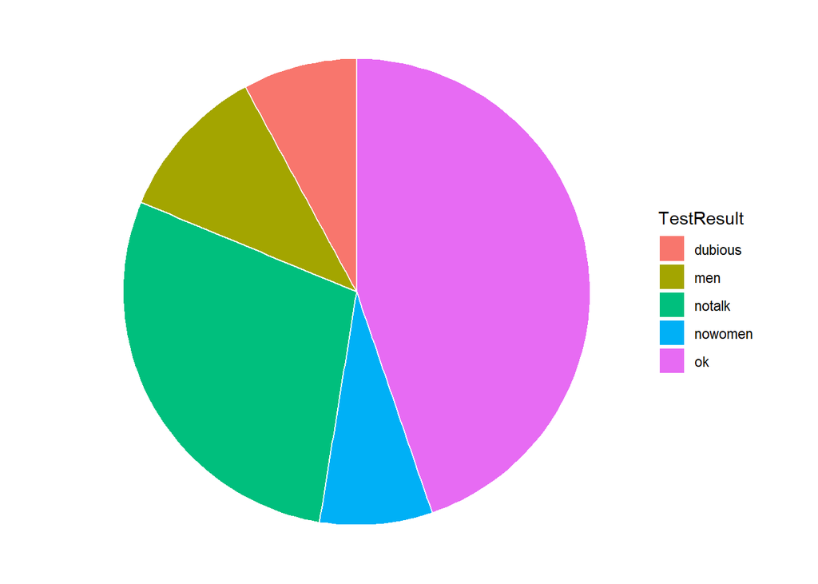

```r
test_table <- table(rawData$clean_test)
testframe = data.frame(test_table)
testframe = testframe %>%
  rename(TestResult = Var1)
ggplot(testframe, aes(x="", y=Freq, fill=TestResult)) +
  geom_bar(stat="identity", width=1, color="white") +
  coord_polar("y", start=0) +
  theme_void()
```

A little less than half of our movies pass the Bechdel test, while among the movies that failed, most had women characters who never spoke to each other in the course of the movie.

Another interesting visualization was the breakdown of the movies that passed and failed the test into more detailed categories that were recorded under `test` and `clean_test`.

While I’m not particularly sure how I’m going to use the abovementioned metrics to drive my data analysis, they are what add subjectivity to this data, and we can alter the results into perhaps `strict` and `generous` test result categories to see whether making the test harder or easier lends some significance to its existence.

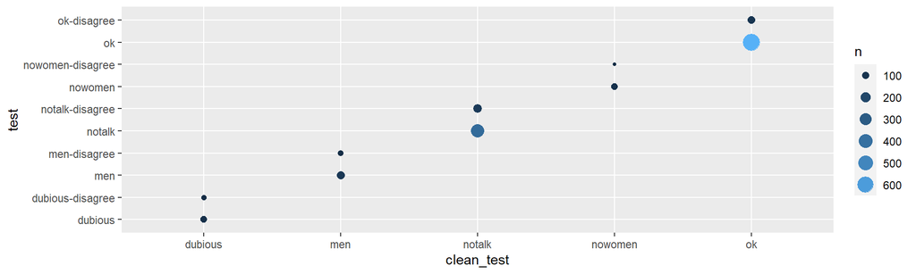

The ‘subjectivity’ breakdown

```r
ggplot(rawData, aes(clean_test, test)) +
  geom_count(aes(color = ..n.., size=..n..)) +
  guides(color = 'legend')
```

Another interesting visualization that I wanted to consider before we move on to financial data is the evolution of movies over the decades; specifically in the aspect of their performance with respect to the Bechdel test. Consdiering the fact that we have a lot more movies from after 1990s than before, making a grid of histograms would produce a variation in levels that can be taken with a grain of salt; what we are interested in is the difference in levels between the `PASS` and `FAIL` values.

I ended up needing the decade attribute after all, but the way I calculated it is mathematical and thus eliminates missing values.

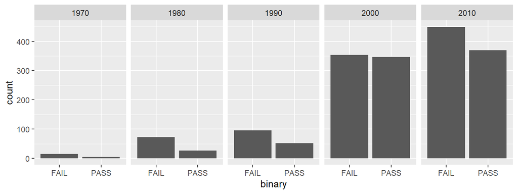

Bechdel test performance over the years

```r
round_to_decade = function(value){
  return(round(value / 10) * 10)
}
rawData$decade = round_to_decade(rawData$year)

ggplot(rawData, aes(binary)) +
  geom_histogram(aes(), stat="count", na.rm=TRUE) +
  facet_grid(~decade)
```

## Financial Data

Let’s take an overarching look at the financial data we’ve got in hand. I found that logarithmic scaling gave us a better idea of the magnitudes of movie budgets.

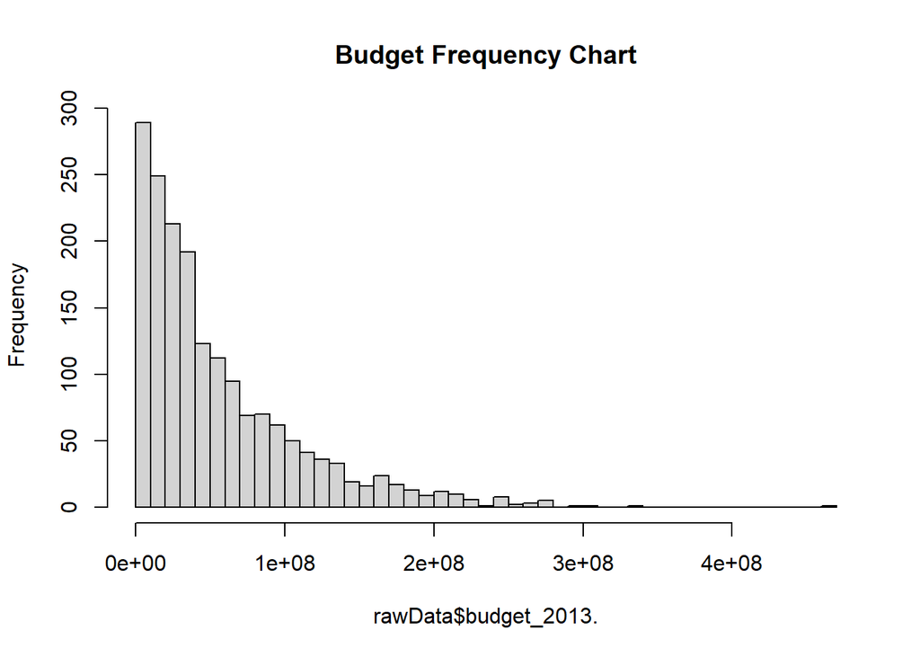

```r
hist(rawData$budget_2013., na.rm=TRUE, breaks=40,
     main="Budget Frequency Chart")
```

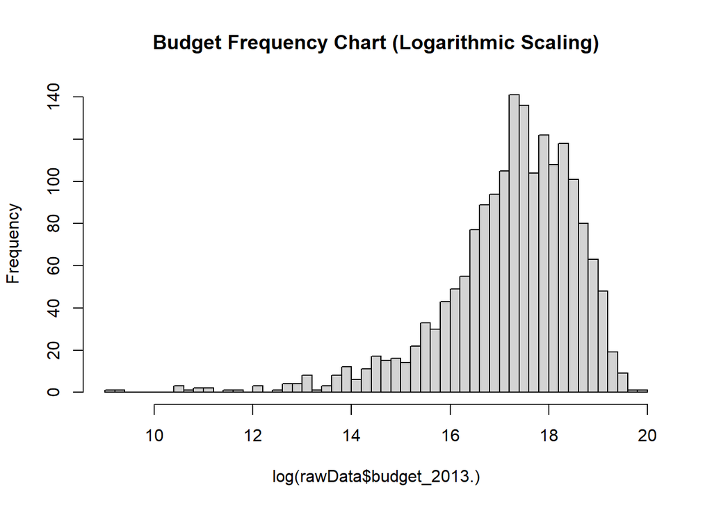

```r
hist(log(rawData$budget_2013.), breaks=40,
     main = "Budget Frequency Chart (Logarithmic Scaling)")
```

There is a fair amount of small-budget and big-budget movies in our dataset, so we’re not limited to just large studio productions or small set indie movies. To dig deeper into financial data, let’s split our domestic and total profits to give us total international profits, and calculate ROI.

```r
rawData$intOnly<-rawData$intgross_2013.-rawData$domgross_2013.

rawData$ROI<-round(rawData$intgross_2013./rawData$budget_2013., 3)
rawData$ROI_dom<-round(rawData$domgross_2013./rawData$budget_2013., 3)
rawData$ROI_int<-round(rawData$intOnly/rawData$budget_2013., 3)
rawData[, c("title","binary", "ROI", "ROI_dom", "ROI_int")]
```

```
## # A tibble: 1,783 x 5
##    title                  binary   ROI ROI_dom ROI_int
##    <chr>                  <chr>  <dbl>   <dbl>   <dbl>
##  1 21 &amp; Over          FAIL   3.25        1   2.25
##  2 Dredd 3D               PASS   0.908       1  -0.092
##  3 12 Years a Slave       FAIL   7.93        1   6.93
##  4 2 Guns                 FAIL   2.17        1   1.17
##  5 42                     FAIL   2.38        1   1.38
##  6 47 Ronin               FAIL   0.648       1  -0.352
##  7 A Good Day to Die Hard FAIL   3.31        1   2.31
##  8 About Time             PASS   7.28        1   6.28
##  9 Admission              PASS   1.38        1   0.385
## 10 After Earth            FAIL   1.88        1   0.88
## # ... with 1,773 more rows
```

```r
failMovies<-rawData[rawData$binary=="FAIL",]
passMovies<-rawData[rawData$binary=="PASS",]

median(failMovies$budget_2013.)
```

```
## [1] 44941739
```

```r
median(passMovies$budget_2013.)
```

```
## [1] 31652174
```

```r
median(rawData$budget_2013.)
```

```
## [1] 3.7e+07
```

Already, there’s a stark shift in budgets, as films that fail the Bechdel test, which is a fairly basic metric to begin with, seem to have more money put behind them. A question that naturally arises is, does that convert into better return on investment though, then?

```r
mean(passMovies$ROI, na.rm=TRUE)
```

```
## [1] 5.291157
```

```r
mean(failMovies$ROI, na.rm=TRUE)
```

```
## [1] 6.930176
```

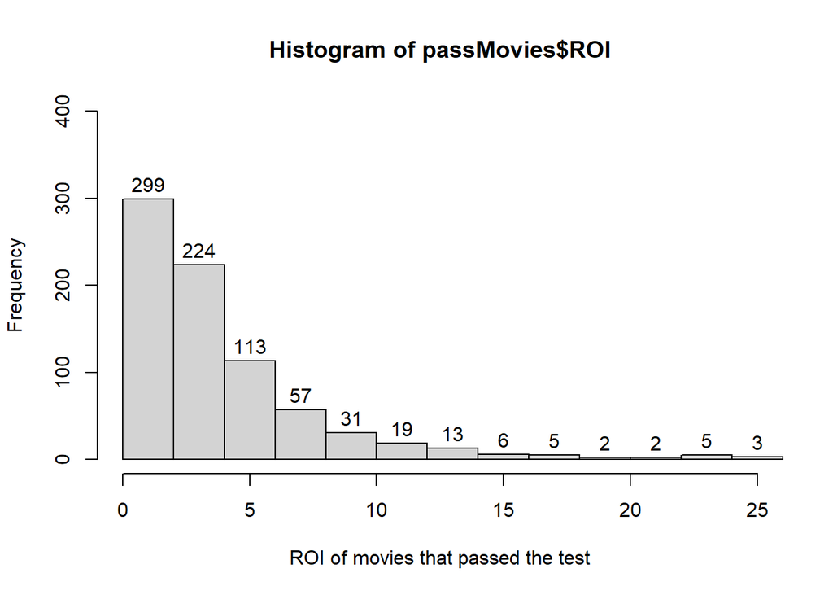

```r
h1 = hist(passMovies$ROI, na.rm=TRUE,
     breaks=250,
     xlim=c(0,25),
     ylim=c(0,400),
     xlab="ROI of movies that passed the test")
text(h1$mids,h1$counts,labels=h1$counts, adj=c(0.5, -0.5))
```

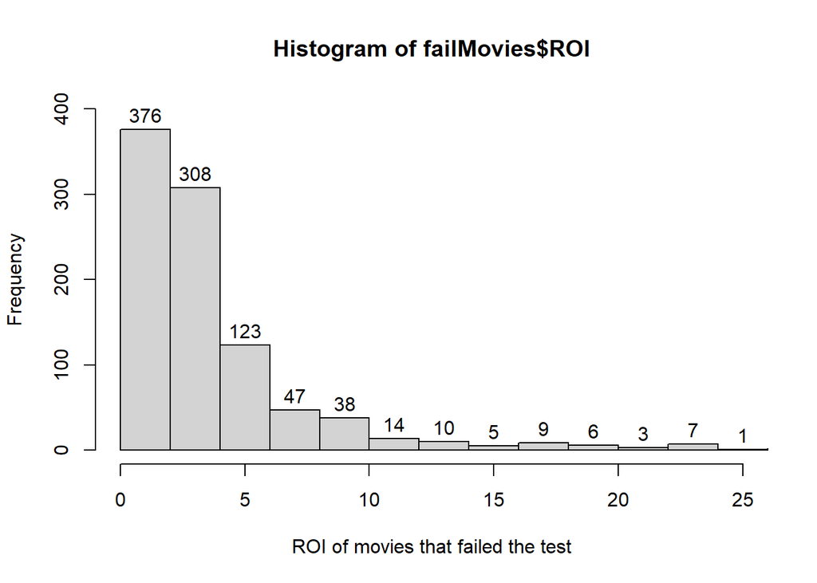

```r
h2 = hist(failMovies$ROI, na.rm=TRUE,
     breaks=250,
     xlim=c(0,25),
     ylim=c(0,400),
     xlab="ROI of movies that failed the test")
text(h2$mids,h2$counts,labels=h2$counts, adj=c(0.5, -0.5))
```

An interesting pointer that comes off this deduction is also that movies that passed the Bechdel test were statistically less likely to be flops (i.e cause losses for a producer by not returning the budget money in sales)

But these are all things bound by various other factors as well, the Bechdel test only considered one of them here. For all we know, the Bechdel test, and by extension, addition of women to a movie, should be insignificant to the ROI of a movie, considering that despite the histogram having lower values all around, the two datasets have very similar frequency distributions all around, which makes me wonder whether the test is significantly correlated to ROIs at all.

Having attributes like IMDb ratings for these movies, or the domestic/international ROI comparisons for these movies would be helpful summaries in further exploring this data.

# Regression Analysis

```r
summary(lm((ROI)~(budget_2013.), data=rawData))
```

```
##
## Call:
## lm(formula = (ROI) ~ (budget_2013.), data = rawData)
##
## Residuals:
##    Min     1Q Median     3Q    Max
##  -8.83  -5.48  -3.31   0.11 422.62
##
## Coefficients:
##                Estimate Std. Error t value Pr(>|t|)
## (Intercept)   8.917e+00  6.964e-01  12.804  < 2e-16 ***
## budget_2013. -4.882e-08  8.897e-09  -5.487 4.68e-08 ***
## ---
## Signif. codes:  0 '***' 0.001 '**' 0.01 '*' 0.05 '.' 0.1 ' ' 1
##
## Residual standard error: 20.65 on 1781 degrees of freedom
## Multiple R-squared:  0.01662,    Adjusted R-squared:  0.01607
## F-statistic:  30.1 on 1 and 1781 DF,  p-value: 4.681e-08
```

Here, it’s clear that ROI and the budget of a film are a negative and significant relationship. Let’s see how this changes when we add the bechdel test factor to this regression equation.

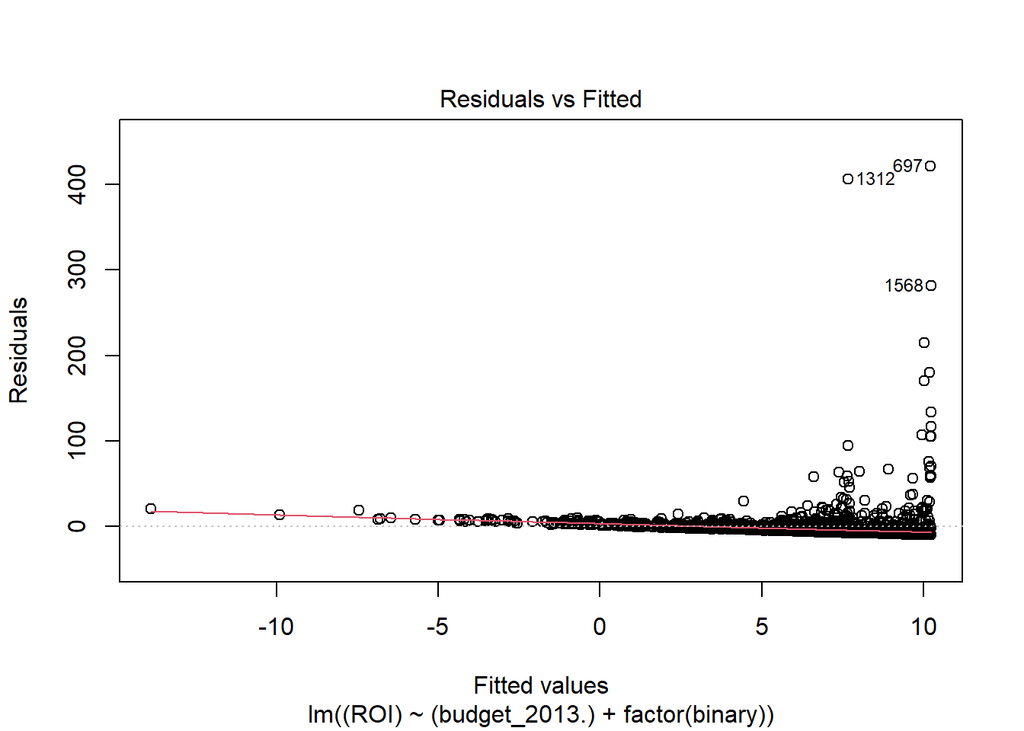

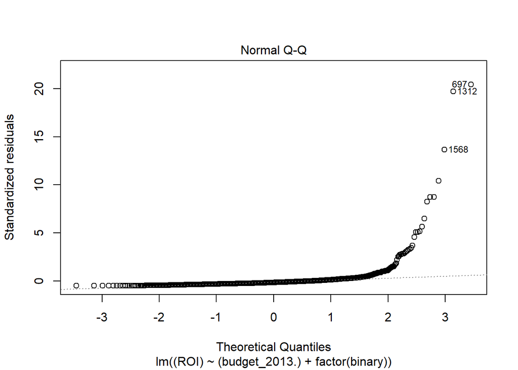

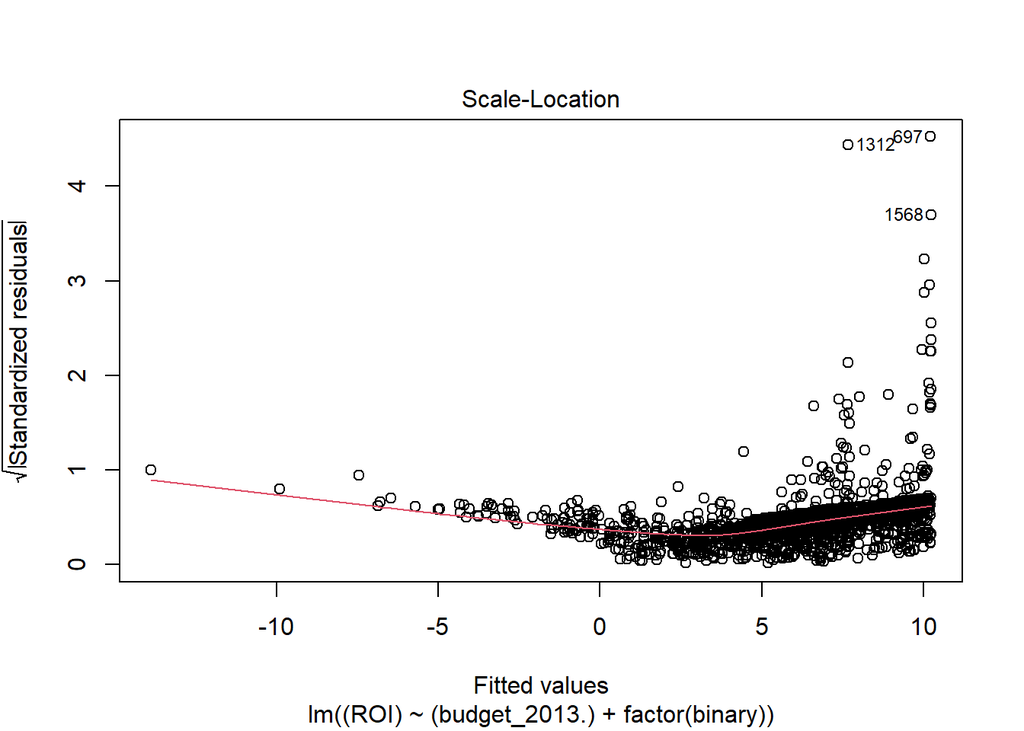

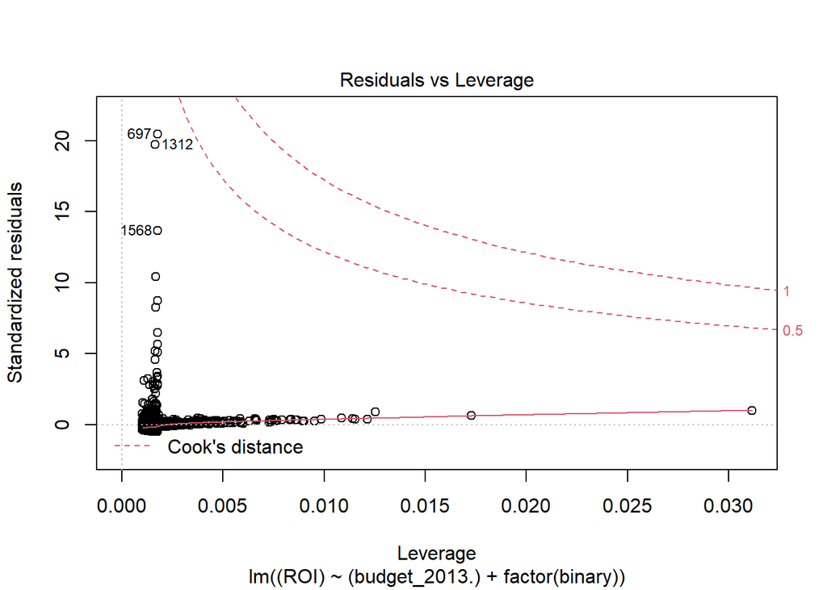

```r
plot(lm((ROI)~(budget_2013.)+factor(binary), data=rawData))
```

```r
summary(lm((ROI)~(budget_2013.)+factor(binary), data=rawData))
```

```
##
## Call:
## lm(formula = (ROI) ~ (budget_2013.) + factor(binary), data = rawData)
##
## Residuals:
##    Min     1Q Median     3Q    Max
## -10.15  -5.53  -3.19   0.20 421.31
##
## Coefficients:
##                      Estimate Std. Error t value Pr(>|t|)
## (Intercept)         1.023e+01  8.685e-01  11.782  < 2e-16 ***
## budget_2013.       -5.225e-08  8.987e-09  -5.814 7.21e-09 ***
## factor(binary)PASS -2.512e+00  9.934e-01  -2.529   0.0115 *
## ---
## Signif. codes:  0 '***' 0.001 '**' 0.01 '*' 0.05 '.' 0.1 ' ' 1
##
## Residual standard error: 20.62 on 1780 degrees of freedom
## Multiple R-squared:  0.02014,    Adjusted R-squared:  0.01904
## F-statistic: 18.29 on 2 and 1780 DF,  p-value: 1.365e-08
```

```r
median(failMovies$ROI, na.rm=T)
```

```
## [1] 2.596
```

```r
median(passMovies$ROI, na.rm=T)
```

```
## [1] 2.702
```

The median ROI of a movie that passes the Bechdel test is 2.702 dollars for each dollar spent. The total median gross return on investment for films that failed was 2.596 dollars for each dollar spent. If we were to take a median ROI plot of movies that didn’t pass the Bechdel test both domestically and internationally, here’s what we get.

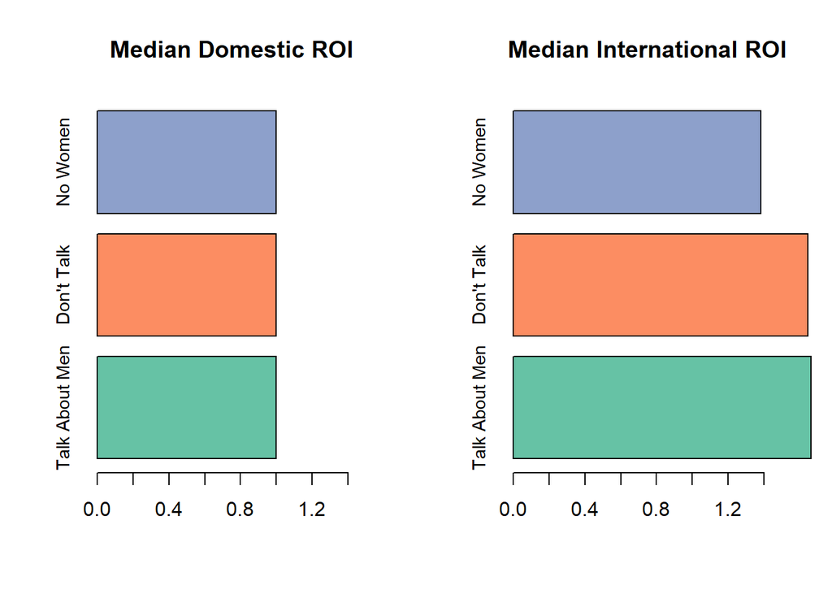

```r
medians_dom <- c((median(rawData$ROI_dom[rawData$clean_test=="men"], na.rm=T)) ,(median(rawData$ROI_dom[rawData$clean_test=="notalk"], na.rm=T)),(median(rawData$ROI_dom[rawData$clean_test=="nowomen"], na.rm=T)))
medians_int <- c((median(rawData$ROI_int[rawData$clean_test=="men"], na.rm=T)) ,(median(rawData$ROI_int[rawData$clean_test=="notalk"], na.rm=T)),(median(rawData$ROI_int[rawData$clean_test=="nowomen"], na.rm=T)))

colors <- brewer.pal(5, "Set2")
par(mfrow=c(1,2))

b1<- barplot(medians_dom, main="Median Domestic ROI", xlim=c(0,1.5), horiz=TRUE,names.arg=c("Talk About Men", "Don't Talk", "No Women"), cex.names=0.9, col=colors)
b2<- barplot(medians_int, main="Median International ROI",xlim=c(0,1.5), horiz=TRUE,names.arg=c("Talk About Men", "Don't Talk", "No Women"), cex.names=0.9, col=colors)
```

While it’s easy to discount these differences in ROI in an unexpected direction towards the fact that lower-budget movies often have higher ROI, it is still a strong indicator of the fact that they’re good for the producer, contrary to the general opinion, and that female-oriented movies are doing well on the box office.

```r
summary(lm(log(intgross_2013.)~log(budget_2013.), data=rawData))
```

```
##
## Call:
## lm(formula = log(intgross_2013.) ~ log(budget_2013.), data = rawData)
##
## Residuals:
##      Min       1Q   Median       3Q      Max
## -10.0816  -0.5953   0.1098   0.7245   4.6417
##
## Coefficients:
##                   Estimate Std. Error t value Pr(>|t|)
## (Intercept)        3.20078    0.38864   8.236 3.41e-16 ***
## log(budget_2013.)  0.86679    0.02249  38.542  < 2e-16 ***
## ---
## Signif. codes:  0 '***' 0.001 '**' 0.01 '*' 0.05 '.' 0.1 ' ' 1
##
## Residual standard error: 1.306 on 1781 degrees of freedom
## Multiple R-squared:  0.4548, Adjusted R-squared:  0.4545
## F-statistic:  1485 on 1 and 1781 DF,  p-value: < 2.2e-16
```

It should be noted here that gross profits vs budgets has a positive *significant* relationship, from the regression analysis. The t-value is large enough to prove that this conclusion isn’t fallacious.

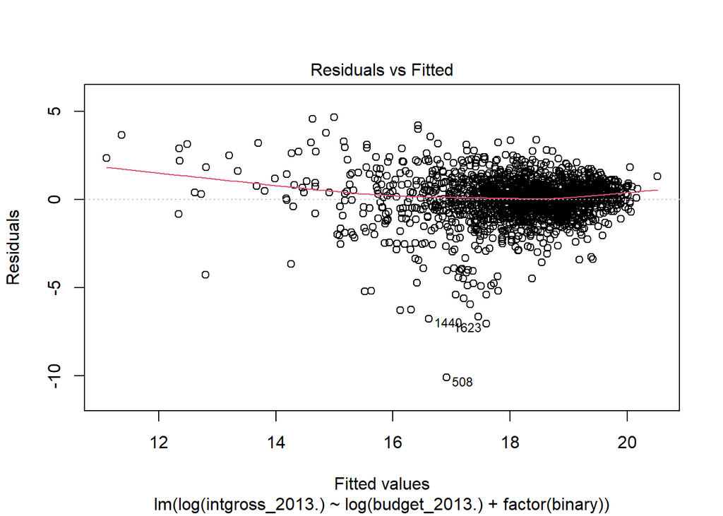

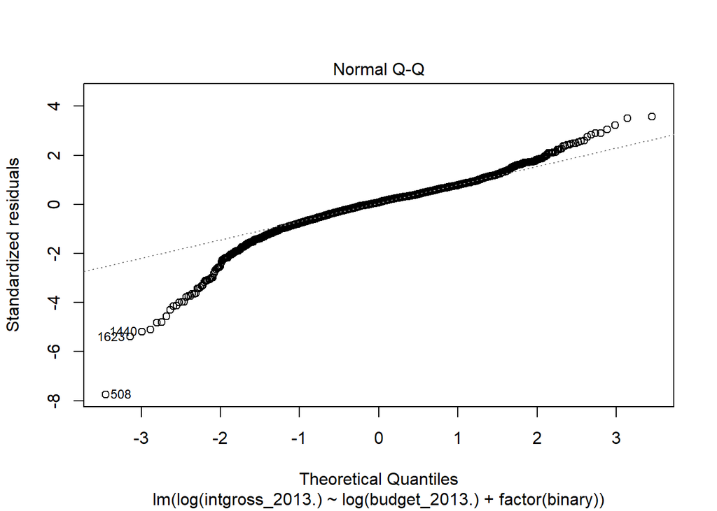

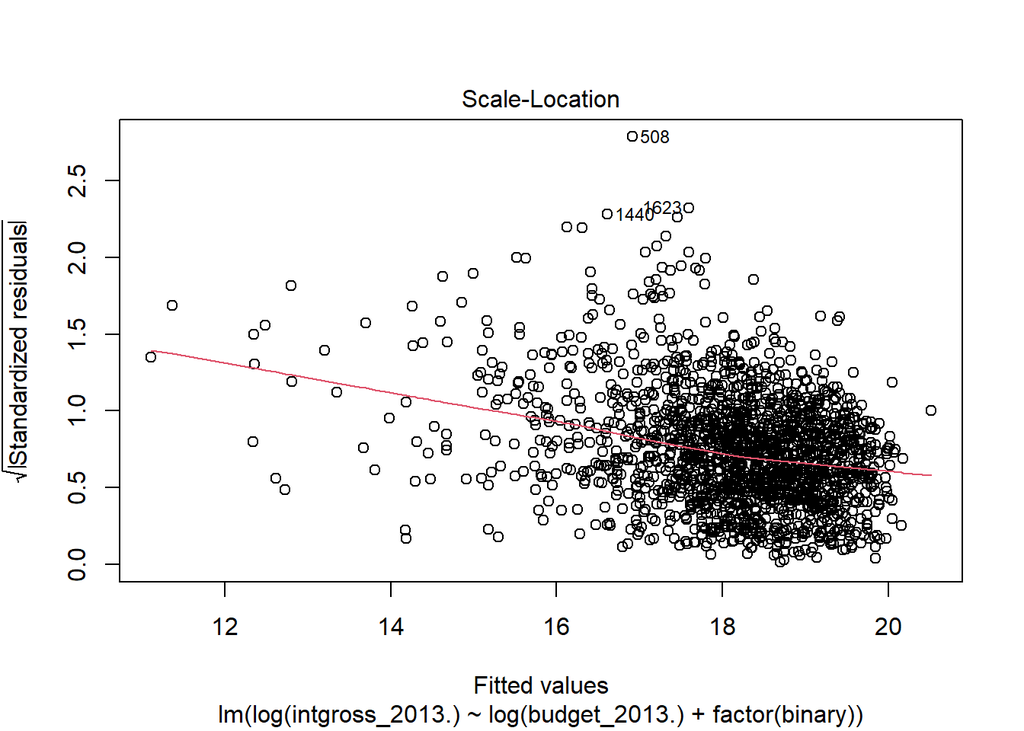

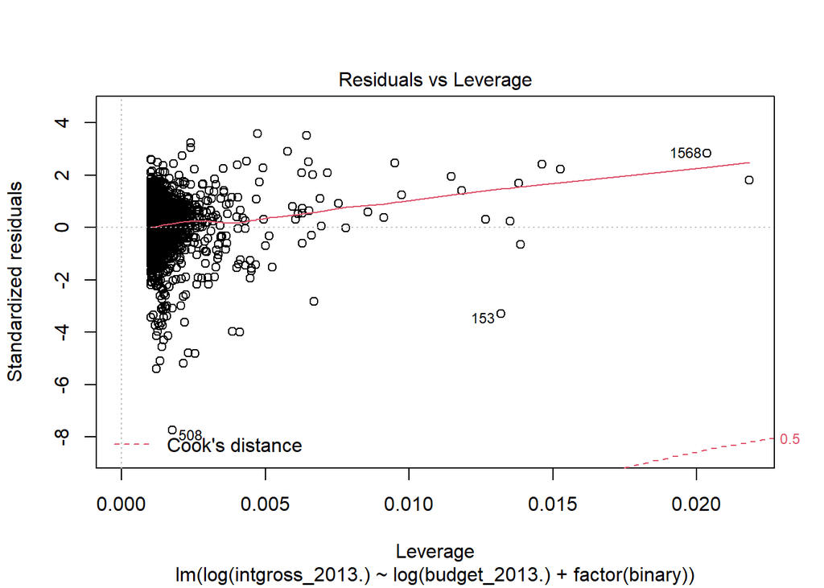

```r
plot(lm(log(intgross_2013.)~log(budget_2013.)+factor(binary), data=rawData))
```

```r
summary(lm(log(intgross_2013.)~log(budget_2013.)+factor(binary), data=rawData))
```

```
##
## Call:
## lm(formula = log(intgross_2013.) ~ log(budget_2013.) + factor(binary),
##     data = rawData)
##
## Residuals:
##      Min       1Q   Median       3Q      Max
## -10.1147  -0.5925   0.1003   0.7194   4.6673
##
## Coefficients:
##                    Estimate Std. Error t value Pr(>|t|)
## (Intercept)         3.27891    0.39591   8.282 2.35e-16 ***
## log(budget_2013.)   0.86394    0.02266  38.130  < 2e-16 ***
## factor(binary)PASS -0.06479    0.06266  -1.034    0.301
## ---
## Signif. codes:  0 '***' 0.001 '**' 0.01 '*' 0.05 '.' 0.1 ' ' 1
##
## Residual standard error: 1.306 on 1780 degrees of freedom
## Multiple R-squared:  0.4551, Adjusted R-squared:  0.4545
## F-statistic: 743.3 on 2 and 1780 DF,  p-value: < 2.2e-16
```

# Conclusion

Hollywood is in the end, a business, with an objective goal in mind to make money. It isn’t beholden to moral values and responsibilities of gender equity and representation. On the other spectrum is the conversation about theatre being the best reflection of the goods and bads in our society; equal representation and equity are a way to change society for the better. Somewhere between this conversation lies this analysis about the Bechdel test, which tries to take a subjective examination of basic female representation in a movie, and tries to objectify it with numbers that matter to that producer who is entrenched in well-found knowledge about the fact that “people don’t want to watch movies with women in them”. There are anecdotal signs that there’s a shift in thinking when it comes to movies featuring women and female relationships. Recently, Hollywood has been able to boast about the success of female-dominated films in the marketplace, which gives me hope.

The biggest movie franchises of the last few years (like the Hunger Games) have had female protagonists (although most of their success has been attributed to their writers and production team rather than the lead actors themselves which is a whole other perception rabbithole that we could base an entirely different project on.)